# Global Child Deprivation Report

# Introduction

**Deprivation of children** among us is still one of the most crying issues of humanity at this epoch of the world. Millions of the world’s children still lack access to basic rights such as education, health care, and shelter, despite global economic growth. UNICEF has an important role to play in monitoring and mitigating these inequities.

This briefing takes a closer look at child deprivation worldwide, through the lens of UNICEF’s indicators, and explores in particular how a country’s wealth status correlates with the extent of deprivation among its children.

Through four visualizations (a global deprivation map, ranking of countries, economic analyses scatterplot, and country-specific time series) pockets of deprivation, we seek to raise public awareness and emphasize the importance of continued international action.

# Key Findings

# Global Deprivation Map

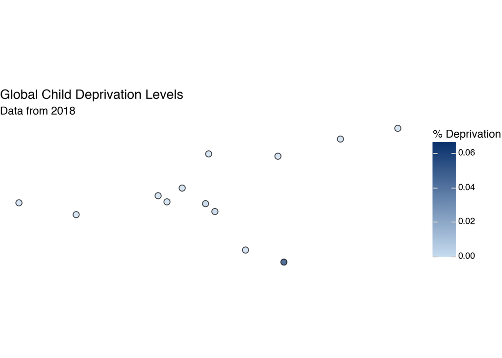

```python
import pandas as pd
import geopandas as gpd
from plotnine import *

indicator_2 = pd.read_csv("unicef_indicator_2.csv")
metadata = pd.read_csv("unicef_metadata.csv")
latest_year = indicator_2["time_period"].max()

deprivation = indicator_2[(indicator_2["time_period"] == latest_year) & (indicator_2["sex"] == "Total")]

world = gpd.read_file("ne_110m_admin_0_countries.shp")
world = world.rename(columns={"ADM0_A3": "alpha_3_code"})
world_data = world.merge(deprivation, on="alpha_3_code")
world_data["long"] = world_data.geometry.centroid.x
world_data["lat"] = world_data.geometry.centroid.y

(
    ggplot(world_data.dropna(subset=["obs_value"]), aes(x="long", y="lat", fill="obs_value")) +
    geom_point(size=3, color="black", alpha=0.7) +
    coord_fixed() +
    theme_void() +
    scale_fill_gradient(name="% Deprivation", low="#c6dbef", high="#08306b") +
    labs(title="Global Child Deprivation Levels", subtitle=f"Data from {latest_year}")
)
```

# Top 10 Countries by Child Deprivation

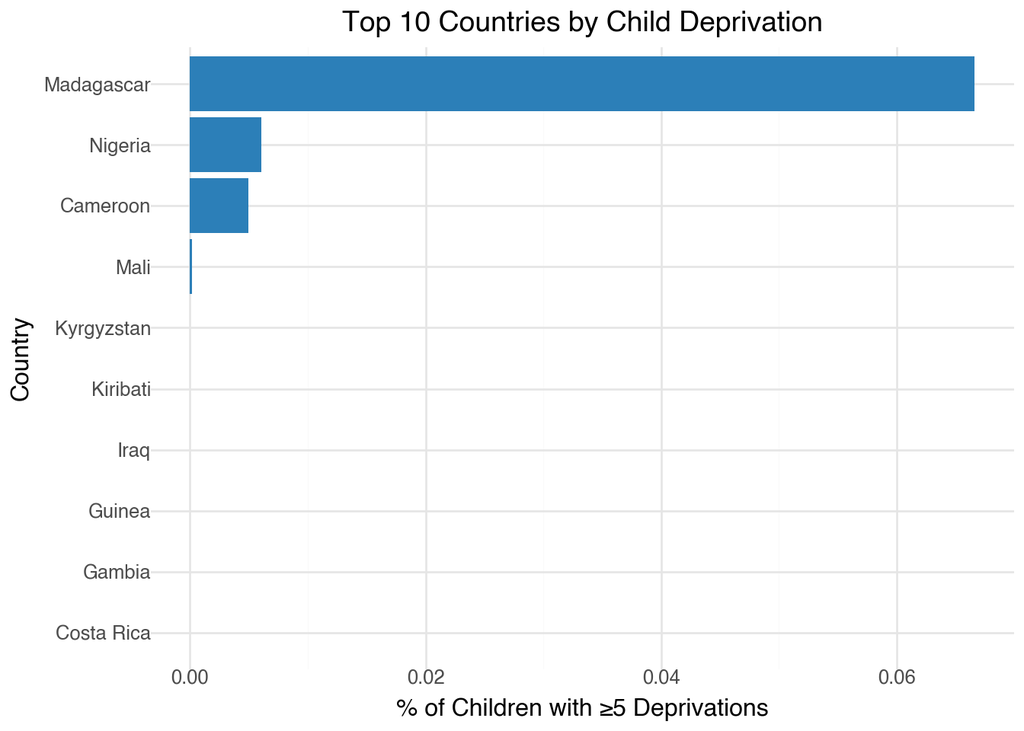

```python
top10 = deprivation.sort_values("obs_value", ascending=False).head(10)

(
    ggplot(top10, aes(x="reorder(country, obs_value)", y="obs_value")) +
    geom_col(fill="#2c7fb8") +
    coord_flip() +
    labs(
        title="Top 10 Countries by Child Deprivation",
        x="Country",
        y="% of Children with ≥5 Deprivations"
    ) +
    theme_minimal(base_size=12) +
    theme(
        axis_title=element_text(weight="bold"),
        plot_title=element_text(size=14, weight="bold")
    )
)
```

# Deprivation vs GDP per Capita

[figure not shown]

```python
data = deprivation.merge(metadata, on="country")
data = data.dropna(subset=["obs_value", "GDP per capita (constant 2015 US$)"])
data = data.rename(columns={"GDP per capita (constant 2015 US$)": "GDP_per_capita"})
data["Deprivation_percent"] = data["obs_value"] * 100

selected_countries = [
    "United States", "India", "Nigeria", "Brazil", "Ethiopia",
    "Bangladesh", "South Africa", "Pakistan", "Mexico", "Indonesia"
]

data = data[data["country"].isin(selected_countries)]
data["label"] = data["country"]

(
    ggplot(data, aes(x="GDP_per_capita", y="Deprivation_percent")) +
    geom_point(size=4, color="#264653", alpha=0.9) +
    geom_text(aes(label="label"), nudge_y=1.5, size=8, ha="left", color="#e76f51") +
    geom_smooth(method="lm", color="#e76f51", size=1.2, se=True, linetype="dashed") +
    scale_x_log10(labels=lambda l: [f"${int(x):,}" for x in l]) +
    labs(
        title="Child Deprivation vs GDP per Capita (10 Key Countries)",
        subtitle="Deprivation rates generally decline as economic capacity increases",
        x="GDP per Capita (Log Scale, USD)",
        y="Child Deprivation Rate (%)"
    ) +
    theme_minimal(base_size=13) +
    theme(
        plot_title=element_text(weight="bold", size=16),
        plot_subtitle=element_text(size=12, color="#4d4d4d"),
        axis_title=element_text(weight="bold"),
        axis_text_x=element_text(rotation=35, ha="right"),
        panel_grid_minor=element_blank()
    )
)
```

# AIDS-related Deaths in Kenya (Time-Series)

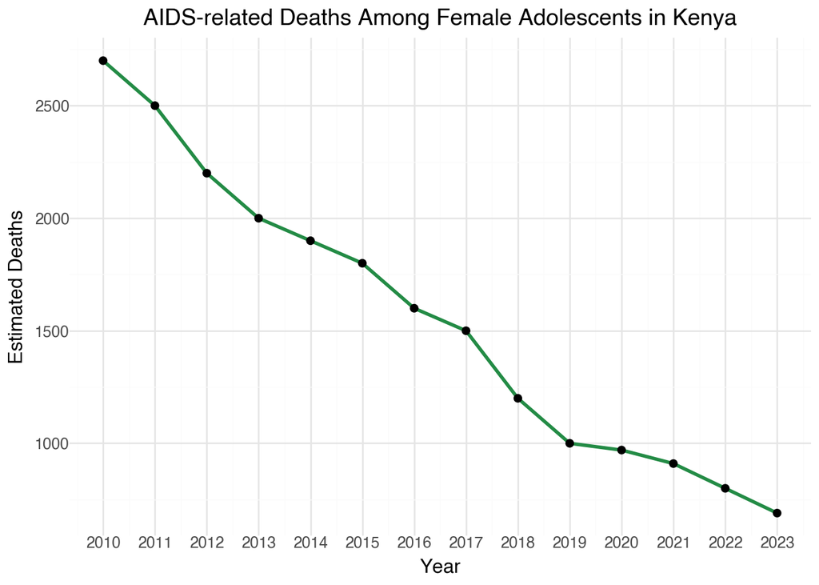

```python
indicator_1 = pd.read_csv("unicef_indicator_1.csv")
indicator_1["obs_value"] = indicator_1["obs_value"].replace("<100", "100")
indicator_1["obs_value"] = pd.to_numeric(indicator_1["obs_value"], errors="coerce")
indicator_1["time_period"] = pd.to_numeric(indicator_1["time_period"], errors="coerce")

kenya = indicator_1.query(
    "country == 'Kenya' and sex == 'Female' and current_age == '10 to 19 years old'"
).dropna(subset=["time_period", "obs_value"])

kenya = kenya.sort_values("time_period")

(
    ggplot(kenya, aes(x="time_period", y="obs_value")) +
    geom_line(color="#238b45", size=1.2) +
    geom_point(color="black", size=2) +
    scale_x_continuous(breaks=sorted(kenya["time_period"].unique().astype(int))) +
    labs(
        title="AIDS-related Deaths Among Female Adolescents in Kenya",
        x="Year",
        y="Estimated Deaths"
    ) +
    theme_minimal(base_size=12) +
    theme(
        axis_title=element_text(weight="bold"),
        plot_title=element_text(size=14, weight="bold")
    )
)
```